# Analysis of 2021 VPHi clinical Survey data

## Usage and fequencies

Frequency of use fro planning intervention:

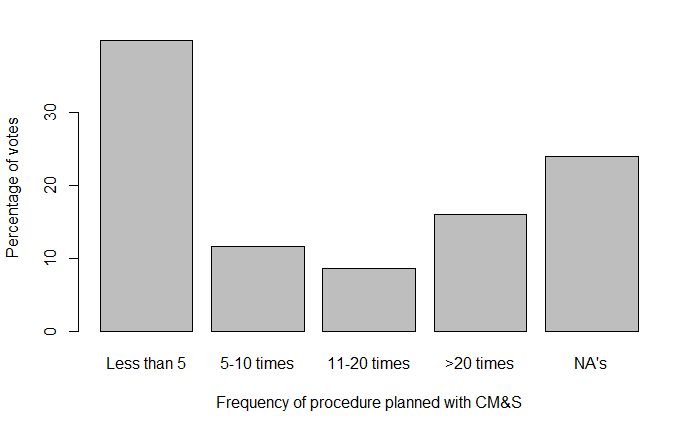

```r
barplot(prop.table(summary(tdf$Q13.how.often, na.omit=TRUE))*100, xlab= "Frequency of procedure planned with CM&S", ylab = "Percentage of votes")
```

What medical applications has CM&S been used for? :

```r
tdf_Q9= select(tdf, starts_with("Q9."))

Q9_TRUE = lapply(tdf_Q9, as.logical) %>% lapply(which) %>% lapply(length) %>% as.data.frame()
rownames(Q9_TRUE) =c("number_votes")

as.data.frame(t(Q9_TRUE)) %>% arrange(desc(number_votes))
```

|  | number_votes |
| --- | --- |
| Q9.Plan.interventions | 79 |
| Q9.Teach | 66 |
| Q9.Study.Pathophysiology | 48 |
| Q9.Enrich.diagnosis | 47 |
| Q9.Compare.different.therapeutic.outcomes..retrospectively. | 45 |
| Q9.Predict.compare.therapeutic.outcomes | 45 |
| Q9.Inform.the.patient.on.disease.progress | 35 |
| Q9.None.of.the.above | 32 |
| Q9.Other.usage | 12 |

```r
NA
NA
```

CM&S method applied to clinical practice

```r
tdf_Q4= select(tdf, starts_with("Q4."))

Q4_TRUE = lapply(tdf_Q4, as.logical) %>% lapply(which) %>% lapply(length) %>% as.data.frame()
rownames(Q4_TRUE) =c("number_votes")

as.data.frame(t(Q4_TRUE)) %>% arrange(desc(number_votes))
```

|  | number_votes |
| --- | --- |
| Q4.Artificial.Interlligence.Machine.Learning | 63 |
| Q4.Multi.scale.1D.3D.modelling | 56 |
| Q4.Finite.Element.Analysis | 55 |
| Q4.Computational.Fluid.Dynamics | 55 |
| Q4.Extended..e.g..Augmented..Virtual..Mixed..reality | 38 |
| Q4.Statistical.Shape.Modelling | 33 |
| Q4.None | 31 |
| Q4.Lumped.parameter.models | 30 |
| Q4.Fluid.structure.Interaction | 14 |
| Q4.Other.method.applied | 5 |

## Association between medical specialty (Q11) and methods used by clinicians (Q4)

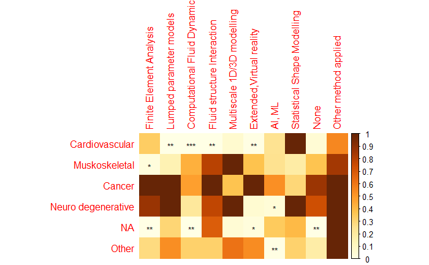

```r
medical_fields = as.list(colnames(tdf)[grep("Q11.",colnames(tdf))])
cms_methods = as.list(colnames(tdf)[grep("Q4.",colnames(tdf))])

Chi_pvalues=matrix(,nrow=length(medical_fields),ncol= length(cms_methods))
rownames(Chi_pvalues) =  list("Cardiovascular","Muskoskeletal","Cancer","Neuro degenerative","NA","Other") #medical_fields
colnames(Chi_pvalues) = list("Finite Element Analysis","Lumped parameter models","Computational Fluid Dynamics","Fluid structure Interaction", "Multiscale 1D/3D modelling","Extended,Virtual reality", "AI, ML","Statistical Shape Modelling","None", "Other method applied") #cms_methods


fish_pvalues=Chi_pvalues


for (m in 1:length(medical_fields)){
  for (c in 1:length(cms_methods)){
    med_field= medical_fields[[m]] # (otherwise use index with grep)
    cms_method= cms_methods[[c]]
    #tab = table(tdf[,med_field],tdf[,cms_method])
    tab = table(select(tdf,all_of(med_field), all_of(cms_method)))
    tab
    #print(list(med_field,cms_method))
    suppressWarnings(chisq <- chisq.test(tab))
    fish <- fisher.test(tab)
    # if (chisq$p.value < 0.05){
    #       corrplot(chisq$residuals, is.cor = FALSE, title=paste(med_field,cms_method), tl.pos=TRUE, method = "number")
    #   par(mar=c(5, 4, 4, 2) + 0.2)
    # }
    Chi_pvalues[m,c] = chisq$p.value
    fish_pvalues[m,c] = fish$p.value
  }
}


#Chi-test of association
corrplot(Chi_pvalues, is.cor = FALSE, method = "color",p.mat= Chi_pvalues, sig.level = c(0.001, 0.01, 0.05), insig = 'label_sig',pch.cex = 0.9)
```

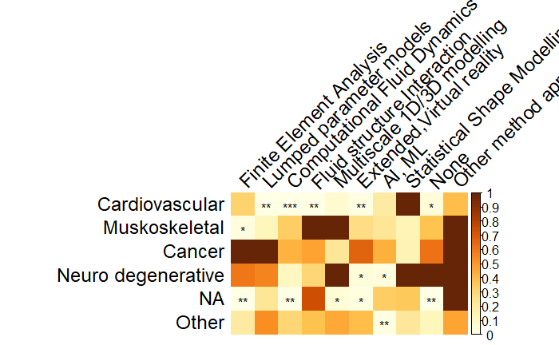

```r
#Fisher of association
corrplot(fish_pvalues, is.cor = FALSE, method = "color",p.mat= fish_pvalues, sig.level = c(0.001, 0.01, 0.05), insig = 'label_sig',pch.cex = 1,tl.col="black", cl.cex= 1, tl.cex=1.5, tl.srt=45)
```

## level of trust & awareness in technologies

### Check for trust distribution

```r
hist(tdf$Q14.Trust.scale, xlab = "Trust scale", cex.axis=1.5, cex.lab=1.5, main=NA)
m=round(mean(tdf$Q14.Trust.scale, na.rm= TRUE),2)
abline(v= m, col="red", lwd= 3)
```

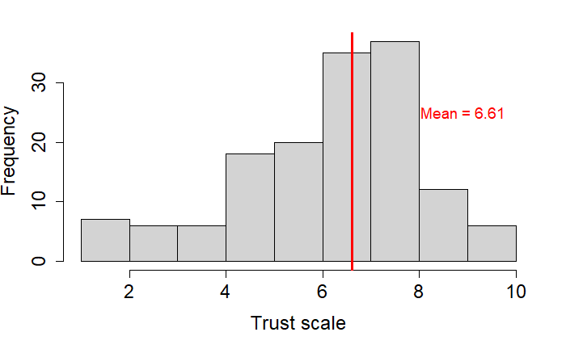

```r
text(x=m*1.35, y= 25, paste("Mean =", m),col="red",cex =1.2)
```

```r
cat("mean: ", mean(tdf$Q14.Trust.scale, na.rm= TRUE),"\n")
```

```
mean:  6.612245
```

```r
cat("standard deviation: ",sd(tdf$Q14.Trust.scale, na.rm = TRUE),"\n")
```

```
standard deviation:  1.970498
```

```r
cat("number of answers (n): ", length((which(!is.na(tdf$Q14.Trust.scale)))),"\n")
```

```
number of answers (n):  147
```

### Check for trust distribution within level of awareness in in silico medicine (probability distribution per level of awareness):

```r
tab2 = table(select(tdf,Q1.Personalized.medicine.awareness, Q14.Trust.scale))
#gplots::balloonplot(tab2, main ="Q1.In.silico.medicine.awareness", xlab ="", ylab="", label = FALSE, show.margins = FALSE)


table(select(tdf,Q1.In.silico.medicine.awareness, Q14.Trust.scale))
```

```
                               Q14.Trust.scale
Q1.In.silico.medicine.awareness  1  2  3  4  5  6  7  8  9 10
               Not at all aware  0  3  1  3  4  3  5  7  1  3
               Slightly aware    3  0  2  1  2  2  9  6  2  0
               Moderately aware  0  1  0  0  6  5 11  5  2  1
               Very aware        0  0  2  2  3  5  6  9  5  1
               Extremely aware   0  0  1  0  3  5  3 10  1  1
```

Relation between trust and in silico medicine awareness:

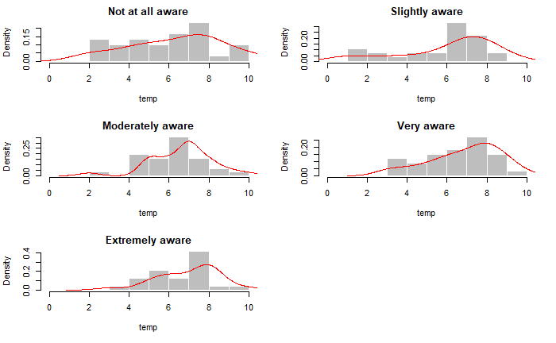

```r
tab2 = table(select(tdf,Q1.In.silico.medicine.awareness, Q14.Trust.scale))

distrib = list()
distribution = vector()
countlength = vector()

# Histograms and density lines
par(mfrow=c(3, 2))
colnames <- dimnames(tab2)[[1]]
for (i in 1:5) {
  temp = vector()
  for (j in 1:10){
    temp= append(temp,rep(j,tab2[i,j]))
  }

  hist(temp,xlim = c(0,10), main=colnames[i], probability=TRUE, col="gray", border="white")
  d <- density(temp)
  lines(d, col="red")


  countlength = append(countlength, length(temp))
  distrib= append(distrib,list(temp))
  distribution= append(distribution,temp)

}
```

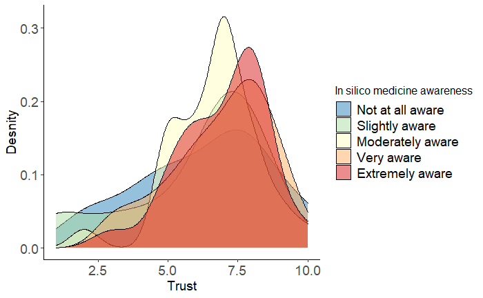

```r
dat <- data.frame(dens = distribution
                  , lines = factor( rep( dimnames(tab2)[[1]], countlength ),levels=levels(tdf$Q1.In.silico.medicine.awareness)))

#Plot.
legend= "In silico medicine awareness"
ggplot(dat, aes(x = dens, fill = lines)) + geom_density(alpha = 0.5) + theme_classic()  + theme(axis.title = element_text(size=14), axis.text = element_text(size=14), legend.text= element_text(size=14), legend.title = element_text(size=12)) + labs(x="Trust", y="Desnity") + scale_fill_brewer(palette = "Spectral", direction = -1, name= legend)
```

### Difference of trust between user groups:

Define Users and non-Users group (based on Q4): create new variable, data$CMnS.Usage

```r
No_answers = (tdf$Q4.Finite.Element.Analysis==FALSE & tdf$Q4.Lumped.parameter.models==FALSE & tdf$Q4.Computational.Fluid.Dynamics==FALSE & tdf$Q4.Fluid.structure.Interaction==FALSE & tdf$Q4.Multi.scale.1D.3D.modelling == FALSE & tdf$Q4.Extended..e.g..Augmented..Virtual..Mixed..reality==FALSE & tdf$Q4.Artificial.Interlligence.Machine.Learning==FALSE & tdf$Q4.Statistical.Shape.Modelling==FALSE & tdf$Q4.Other.method.applied==FALSE & tdf$Q4.None==FALSE)

# # display ID of those observations that do not contain any answers:
# which(No_answers)

data = filter(tdf, !No_answers)

##
data = dplyr::mutate(data, CMnS.Usage = "Users")
data$CMnS.Usage[data$Q4.None==FALSE]="Non-Users"
data$CMnS.Usage = as.factor(data$CMnS.Usage)
```

### Q14 (trust) and Q4 (usage)

Is there a difference of trust between those who have even applied CM&S to their practive and those who haven’t.

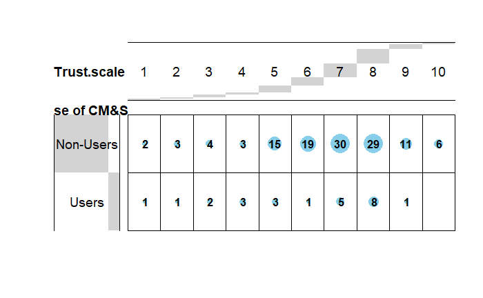

```r
tab_Q4Q14 = table(dplyr::select(data, CMnS.Usage, Q14.Trust.scale))
# tab_Q4Q14
# prop.table(tab_Q4Q14, margin = 1)*100
# prop.table(tab_Q4Q14, margin = 2)*100
gplots::balloonplot(t(tab_Q4Q14), main = "",ylab = "Use of CM&S",label = TRUE, show.margins = FALSE, text.size=1.2)
```

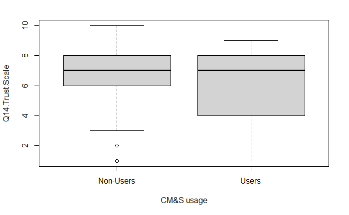

```r
boxplot(data$Q14.Trust.scale~ data$CMnS.Usage, ylab= "Q14.Trust.Scale", xlab= "CM&S usage")
```

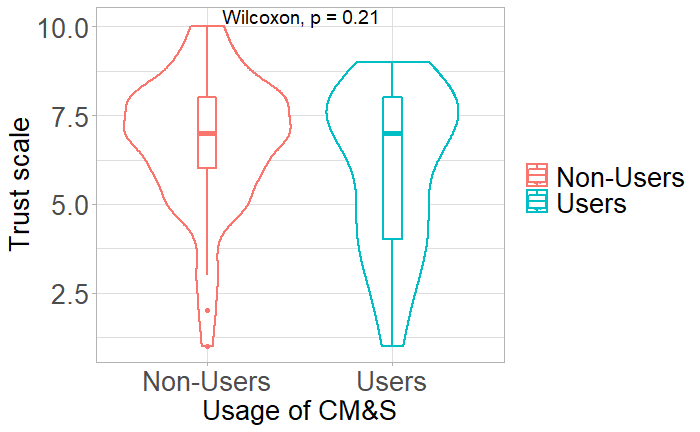

```r
# Violin plot basic
p <- ggplot(data, aes(x= CMnS.Usage, y= Q14.Trust.scale, color=CMnS.Usage)) +
  geom_violin(trim=TRUE, size =1)  + stat_compare_means(method = "wilcox.test",label.y= 10.1, label.x = 1.25, size =5)
p + geom_boxplot(width=0.1, size =1) + theme_light() + theme(axis.title= element_text(size=20), axis.text = element_text(size = 20), legend.title = element_blank(), legend.text = element_text(size=20)) + labs(x = "Usage of CM&S", y="Trust scale")
```